# Qualifying Standards for World Masters Championships

Friedrich Faber, Marianne Huebner, David Meltzer, Les Simonton

05 September 2018

# 1 Trend for IWF world championships across years

## 1.1 Number of lifters

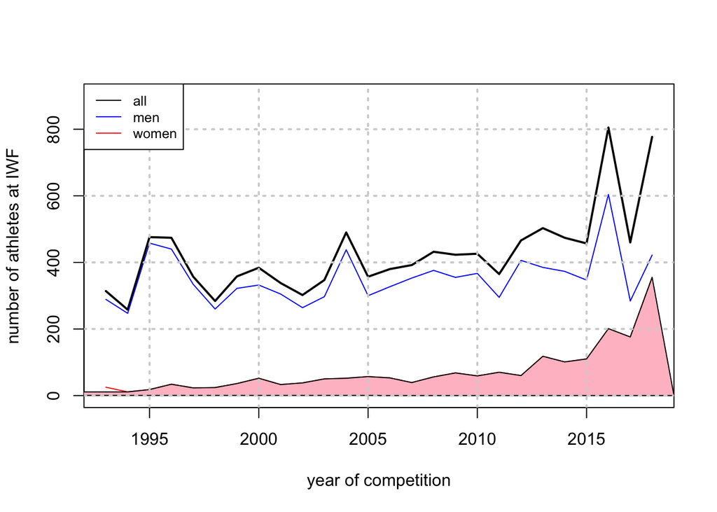

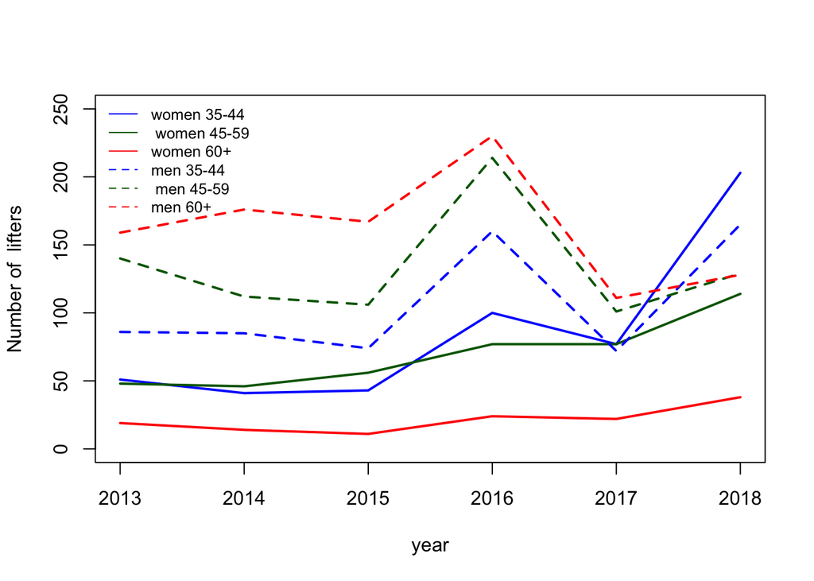

The increase in women participations has been seen in US National competitions for a while, so that the number of women surpassed those of the number of men in recent years. In particular, among the US athletes in Barcelona the women weightlifters outnumbered the men weightlifters as was also the case for a couple of other countries.

Of note is that the number of men in older age groups outnumbers the number of men in younger age groups.

## 1.2 Number of lifters by country and gender

Number of male lifters

| countries | IWF2013 | IWF2014 | IWF2015 | IWF2016 | IWF2017 | IWF2018 |
| --- | --- | --- | --- | --- | --- | --- |
| ARM | 0 | 0 | 0 | 0 | 1 | 0 |
| AUS | 1 | 2 | 0 | 4 | 22 | 4 |
| AUT | 6 | 9 | 4 | 24 | 2 | 5 |
| AZE | 9 | 0 | 5 | 1 | 0 | 0 |
| BEL | 1 | 1 | 1 | 1 | 0 | 1 |
| BIH | 2 | 0 | 0 | 1 | 0 | 0 |
| BLR | 7 | 5 | 4 | 12 | 1 | 0 |
| BRA | 0 | 0 | 0 | 1 | 0 | 1 |
| BUL | 1 | 2 | 0 | 2 | 3 | 9 |
| CAN | 12 | 5 | 4 | 8 | 2 | 11 |
| CHI | 0 | 0 | 0 | 0 | 1 | 7 |
| CHN | 0 | 0 | 3 | 0 | 0 | 0 |
| CRO | 2 | 0 | 0 | 0 | 0 | 0 |
| CZE | 4 | 4 | 6 | 27 | 4 | 8 |
| DEN | 2 | 20 | 3 | 4 | 1 | 2 |
| ECU | 0 | 0 | 0 | 0 | 0 | 1 |
| ESA | 0 | 0 | 0 | 0 | 0 | 2 |
| ESP | 7 | 3 | 3 | 6 | 0 | 44 |
| EST | 2 | 3 | 5 | 3 | 2 | 2 |
| FIN | 9 | 19 | 97 | 23 | 6 | 14 |
| FRA | 21 | 25 | 22 | 53 | 22 | 45 |
| GBR | 6 | 14 | 12 | 16 | 9 | 21 |
| GER | 55 | 63 | 33 | 136 | 19 | 48 |
| GRE | 6 | 3 | 0 | 1 | 5 | 0 |
| GUY | 0 | 0 | 0 | 0 | 1 | 0 |
| HUN | 9 | 10 | 6 | 23 | 2 | 11 |
| IND | 1 | 1 | 1 | 1 | 2 | 3 |
| IRI | 1 | 1 | 14 | 20 | 10 | 0 |
| IRL | 0 | 1 | 1 | 4 | 0 | 1 |
| ISL | 0 | 0 | 1 | 0 | 0 | 1 |
| ISR | 5 | 3 | 3 | 4 | 1 | 4 |
| ITA | 10 | 8 | 5 | 11 | 0 | 10 |
| JPN | 28 | 29 | 26 | 20 | 33 | 22 |
| KAZ | 0 | 0 | 0 | 2 | 0 | 0 |
| LBN | 0 | 0 | 0 | 0 | 2 | 4 |
| LIB | 4 | 5 | 0 | 5 | 0 | 0 |
| LTU | 5 | 5 | 1 | 7 | 2 | 0 |
| LUX | 0 | 0 | 0 | 1 | 0 | 0 |
| MAS | 2 | 1 | 1 | 0 | 1 | 2 |
| MGL | 3 | 1 | 0 | 1 | 3 | 0 |
| MON | 1 | 1 | 0 | 0 | 0 | 0 |
| NCA | 0 | 0 | 0 | 0 | 0 | 1 |
| NED | 1 | 1 | 1 | 2 | 0 | 2 |
| NOR | 3 | 15 | 6 | 11 | 2 | 11 |
| NZL | 1 | 0 | 0 | 0 | 29 | 0 |
| PAN | 0 | 0 | 0 | 0 | 1 | 2 |
| POL | 15 | 13 | 10 | 32 | 12 | 5 |
| POR | 0 | 0 | 0 | 7 | 0 | 14 |
| ROU | 0 | 0 | 0 | 0 | 0 | 1 |
| RSA | 0 | 1 | 1 | 7 | 1 | 5 |
| RUS | 52 | 29 | 19 | 22 | 27 | 0 |
| SCO | 2 | 0 | 0 | 0 | 0 | 0 |
| SMR | 1 | 1 | 0 | 0 | 0 | 0 |
| SUI | 0 | 0 | 1 | 4 | 0 | 1 |
| SVK | 9 | 1 | 1 | 15 | 1 | 6 |
| SWE | 18 | 20 | 24 | 30 | 4 | 8 |
| TPE | 0 | 0 | 0 | 0 | 0 | 1 |
| TUN | 0 | 0 | 0 | 0 | 0 | 1 |
| TUR | 0 | 1 | 0 | 7 | 2 | 0 |
| UKR | 21 | 8 | 0 | 10 | 0 | 0 |
| URU | 0 | 0 | 2 | 1 | 1 | 4 |
| USA | 24 | 38 | 18 | 33 | 47 | 76 |
| UZB | 2 | 1 | 2 | 1 | 0 | 0 |
| VEN | 14 | 0 | 1 | 0 | 0 | 1 |
| Sum | 385 | 373 | 347 | 604 | 284 | 422 |

Number of female lifters

| countries | IWF2013 | IWF2014 | IWF2015 | IWF2016 | IWF2017 | IWF2018 |
| --- | --- | --- | --- | --- | --- | --- |
| AUS | 14 | 8 | 4 | 7 | 49 | 24 |
| AUT | 1 | 2 | 2 | 8 | 1 | 3 |
| AZE | 2 | 0 | 1 | 0 | 0 | 0 |
| BEL | 1 | 1 | 0 | 2 | 1 | 1 |
| BLR | 0 | 0 | 0 | 1 | 0 | 0 |
| BRA | 0 | 0 | 0 | 0 | 0 | 2 |
| CAN | 6 | 4 | 4 | 5 | 8 | 18 |
| CYP | 1 | 2 | 1 | 1 | 1 | 0 |
| CZE | 0 | 0 | 0 | 2 | 0 | 0 |
| DEN | 4 | 11 | 9 | 9 | 1 | 9 |
| ESP | 0 | 1 | 2 | 7 | 0 | 21 |
| EST | 0 | 0 | 0 | 1 | 0 | 1 |
| FIN | 2 | 7 | 31 | 18 | 4 | 21 |
| FRA | 9 | 3 | 3 | 15 | 3 | 16 |
| GBR | 3 | 8 | 12 | 19 | 4 | 33 |
| GER | 7 | 9 | 6 | 27 | 3 | 16 |
| GRE | 4 | 3 | 0 | 0 | 0 | 0 |
| HUN | 3 | 1 | 2 | 11 | 1 | 5 |
| INA | 0 | 0 | 0 | 0 | 0 | 1 |
| IRL | 2 | 1 | 1 | 3 | 1 | 3 |
| ISL | 0 | 0 | 0 | 0 | 0 | 3 |
| ITA | 9 | 5 | 3 | 11 | 1 | 8 |
| JPN | 4 | 1 | 2 | 0 | 2 | 0 |
| LIB | 1 | 0 | 0 | 0 | 0 | 0 |
| MAR | 0 | 0 | 0 | 0 | 0 | 1 |
| MAS | 0 | 0 | 0 | 0 | 1 | 1 |
| MGL | 2 | 1 | 1 | 2 | 3 | 1 |
| MON | 0 | 0 | 0 | 1 | 0 | 0 |
| NED | 0 | 0 | 1 | 5 | 1 | 9 |
| NOR | 0 | 2 | 1 | 0 | 0 | 1 |
| NZL | 1 | 0 | 0 | 0 | 46 | 10 |
| POL | 0 | 0 | 0 | 0 | 0 | 2 |
| POR | 0 | 0 | 0 | 1 | 0 | 5 |
| PUR | 1 | 0 | 0 | 0 | 0 | 0 |
| RSA | 0 | 0 | 0 | 6 | 1 | 12 |
| RUS | 3 | 2 | 0 | 1 | 1 | 0 |
| SCO | 4 | 0 | 0 | 0 | 0 | 0 |
| SGP | 0 | 0 | 0 | 0 | 1 | 0 |
| SIN | 0 | 0 | 0 | 1 | 0 | 1 |
| SUI | 0 | 0 | 0 | 0 | 1 | 0 |
| SWE | 0 | 4 | 3 | 4 | 0 | 11 |
| TAH | 1 | 0 | 0 | 0 | 0 | 0 |
| UKR | 1 | 1 | 0 | 0 | 0 | 0 |
| USA | 25 | 24 | 21 | 33 | 41 | 116 |
| VEN | 7 | 0 | 0 | 0 | 0 | 0 |
| Sum | 118 | 101 | 110 | 201 | 176 | 355 |

# 2 Athletes who registered and competed

IWF 2016 in Heinsheim, Germany

|  | men |  |  | women |  |  |
| --- | --- | --- | --- | --- | --- | --- |
| age | start | lift | %miss | start | lift | %miss |
| 35-39 | 88 | 74 | 15.9 | 64 | 59 | 7.8 |
| 40-44 | 103 | 86 | 16.5 | 51 | 41 | 19.6 |
| 45-49 | 88 | 78 | 11.4 | 36 | 33 | 8.3 |
| 50-54 | 90 | 69 | 23.3 | 26 | 26 | 0 |
| 55-59 | 77 | 67 | 13 | 18 | 18 | 0 |
| 60-64 | 69 | 61 | 11.6 | 15 | 14 | 6.7 |
| 65-69 | 71 | 62 | 12.7 | 5 | 5 | 0 |
| 70-74 | 49 | 42 | 14.3 | 4 | 4 | 0 |
| 75-79 | 42 | 36 | 14.3 | 1 | 1 | 0 |
| 80+ | 35 | 29 | 17.1 | 0 | 0 | NaN |

| participation | number |
| --- | --- |
| men_start | 712 |
| men_lift | 604 |
| women_start | 220 |
| women_lift | 201 |

IWF 2018 in Barcelona, Spain

|  | men |  |  | women |  |  |
| --- | --- | --- | --- | --- | --- | --- |
| age | start | lift | % miss | start | lift | % miss |
| 35-39 | 100 | 93 | 7 | 130 | 120 | 7.7 |
| 40-44 | 84 | 72 | 14.3 | 90 | 83 | 7.8 |
| 45-49 | 59 | 49 | 16.9 | 56 | 51 | 8.9 |
| 50-54 | 46 | 42 | 8.7 | 44 | 40 | 9.1 |
| 55-59 | 42 | 38 | 9.5 | 24 | 23 | 4.2 |
| 60-64 | 36 | 31 | 13.9 | 21 | 21 | 0 |
| 65-69 | 32 | 32 | 0 | 13 | 13 | 0 |
| 70-74 | 31 | 29 | 6.5 | 4 | 4 | 0 |
| 75-79 | 21 | 21 | 0 | 0 | 0 | NaN |
| 80+ | 15 | 15 | 0 | 0 | 0 | NaN |

| participation | number |
| --- | --- |
| men_start | 466 |
| men_lift | 422 |
| women_start | 382 |
| women_lift | 355 |

The proportion of men who registered for IWF 2016 but did not lift is: 15.2 %.

The proportion of women who registered for IWF 2016 but did not lift is: 8.6 %.

The proportion of men who registered for IWF 2018 but did not lift is: 9.4 %.

The proportion of women who registered for IWF 2018 but did not lift is: 7.1 %.

# 3 Proportion of lifters whose total was below the qualifying total

|  |  | Women |  |  |  | Men |  |  |  |
| --- | --- | --- | --- | --- | --- | --- | --- | --- | --- |
| Year | Age | n | tot>qual | % less |  | n | tot>qual | % less |  |
| 2013 | 35-44 | 51 | 46 | 10.9 | f | 86 | 69 | 24.6 | m |
| 2013 | 45-59 | 48 | 41 | 17.1 | f | 140 | 108 | 29.6 | m |
| 2013 | 60+ | 19 | 15 | 26.7 | f | 159 | 134 | 18.7 | m |
| 2014 | 35-44 | 41 | 36 | 13.9 | f | 85 | 73 | 16.4 | m |
| 2014 | 45-59 | 46 | 41 | 12.2 | f | 112 | 89 | 25.8 | m |
| 2014 | 60+ | 14 | 12 | 16.7 | f | 176 | 146 | 20.5 | m |
| 2015 | 35-44 | 43 | 38 | 13.2 | f | 74 | 61 | 21.3 | m |
| 2015 | 45-59 | 56 | 48 | 16.7 | f | 106 | 83 | 27.7 | m |
| 2015 | 60+ | 11 | 10 | 10 | f | 167 | 146 | 14.4 | m |
| 2016 | 35-44 | 100 | 92 | 8.7 | f | 160 | 121 | 32.2 | m |
| 2016 | 45-59 | 77 | 70 | 10 | f | 214 | 163 | 31.3 | m |
| 2016 | 60+ | 24 | 20 | 20 | f | 230 | 189 | 21.7 | m |
| 2017 | 35-44 | 77 | 70 | 10 | f | 72 | 59 | 22 | m |
| 2017 | 45-59 | 77 | 68 | 13.2 | f | 101 | 78 | 29.5 | m |
| 2017 | 60+ | 22 | 21 | 4.8 | f | 111 | 94 | 18.1 | m |

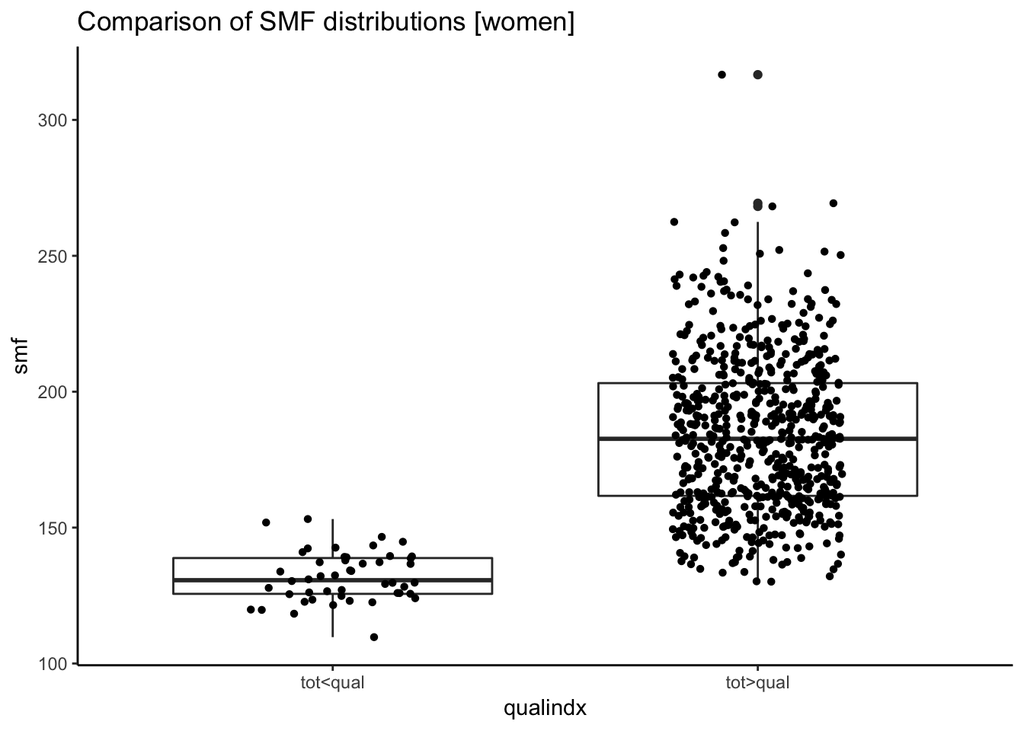

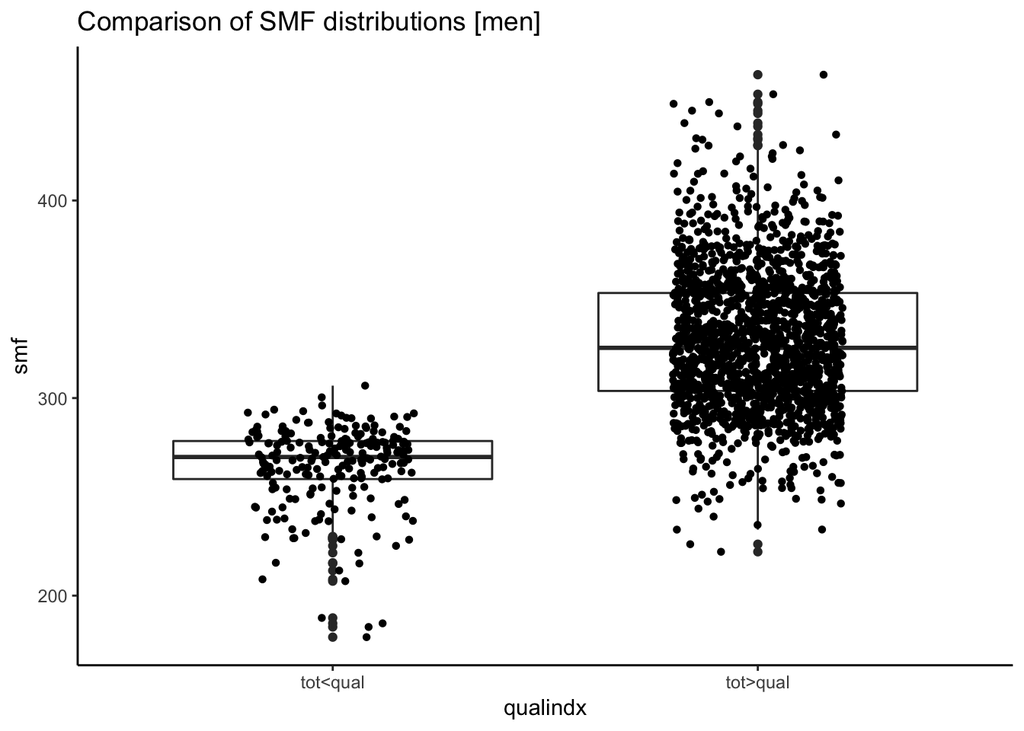

# 4 Qualifying standards based on SMF

USA SMF cutoffs for National Masters Championships

| .rownames | X1 | X2 | X3 | X4 | X5 | X6 | X7 | X8 | X9 | X10 |
| --- | --- | --- | --- | --- | --- | --- | --- | --- | --- | --- |
| agecat | 35-39 | 40-44 | 45-49 | 50-54 | 55-59 | 60-64 | 65-69 | 70-74 | 75-79 | 80+ |
| men.smf | 265 | 265 | 265 | 265 | 250 | 250 | 240 | 230 | 230 | 230 |
| women.smf | 150 | 150 | 150 | 150 | 140 | 130 | 130 | 130 | 130 | 130 |

Number of lifters reaching the (USA) SMF cutoff

| year | agegrp | sex | lifters | num.qual | pct |
| --- | --- | --- | --- | --- | --- |
| 2013 | 35-44 | f | 51 | 45 | 86.7 |
| 2013 | 45-59 | f | 48 | 37 | 70.3 |
| 2013 | 60+ | f | 19 | 15 | 73.3 |
| 2014 | 35-44 | f | 41 | 36 | 86.1 |
| 2014 | 45-59 | f | 46 | 40 | 85 |
| 2014 | 60+ | f | 14 | 12 | 83.3 |
| 2015 | 35-44 | f | 43 | 35 | 77.1 |
| 2015 | 45-59 | f | 56 | 43 | 69.8 |
| 2015 | 60+ | f | 11 | 10 | 90 |
| 2016 | 35-44 | f | 100 | 89 | 87.6 |
| 2016 | 45-59 | f | 77 | 65 | 81.5 |
| 2016 | 60+ | f | 24 | 21 | 85.7 |
| 2017 | 35-44 | f | 77 | 68 | 86.8 |
| 2017 | 45-59 | f | 77 | 58 | 67.2 |
| 2017 | 60+ | f | 22 | 21 | 95.2 |
| 2018 | 35-44 | f | 203 | 178 | 86 |
| 2018 | 45-59 | f | 114 | 99 | 84.8 |
| 2018 | 60+ | f | 38 | 36 | 94.4 |
| 2013 | 35-44 | m | 86 | 71 | 78.9 |
| 2013 | 45-59 | m | 140 | 123 | 86.2 |
| 2013 | 60+ | m | 159 | 142 | 88 |
| 2014 | 35-44 | m | 85 | 80 | 93.8 |
| 2014 | 45-59 | m | 112 | 104 | 92.3 |
| 2014 | 60+ | m | 176 | 157 | 87.9 |
| 2015 | 35-44 | m | 74 | 67 | 89.6 |
| 2015 | 45-59 | m | 106 | 94 | 87.2 |
| 2015 | 60+ | m | 167 | 154 | 91.6 |
| 2016 | 35-44 | m | 160 | 139 | 84.9 |
| 2016 | 45-59 | m | 214 | 189 | 86.8 |
| 2016 | 60+ | m | 230 | 200 | 85 |
| 2017 | 35-44 | m | 72 | 68 | 94.1 |
| 2017 | 45-59 | m | 101 | 90 | 87.8 |
| 2017 | 60+ | m | 111 | 100 | 89 |
| 2018 | 35-44 | m | 165 | 148 | 88.5 |
| 2018 | 45-59 | m | 129 | 116 | 88.8 |
| 2018 | 60+ | m | 128 | 120 | 93.3 |

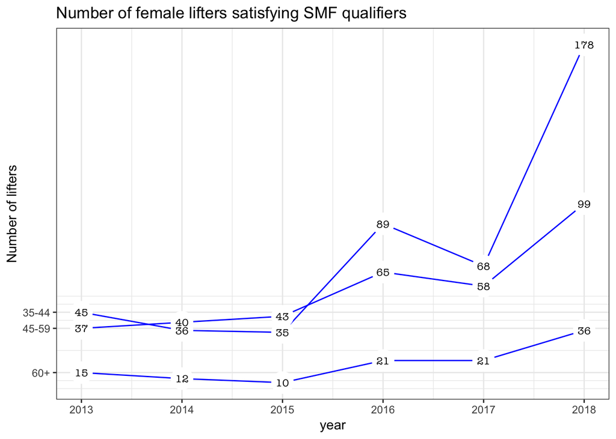

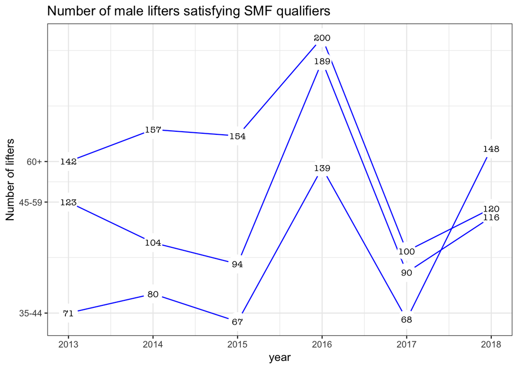

This results in the following number of lifters in the past World championships

| year | women.smf | men.smf | qual.n | qual.pct | actual.n |
| --- | --- | --- | --- | --- | --- |
| 2013 | 97 | 336 | 433 | 86 | 503 |
| 2014 | 88 | 341 | 429 | 91 | 474 |
| 2015 | 88 | 315 | 403 | 88 | 457 |
| 2016 | 175 | 528 | 703 | 87 | 805 |
| 2017 | 147 | 258 | 405 | 88 | 460 |
| 2018 | 313 | 384 | 697 | 90 | 777 |

Number of male lifters reaching the SMF cutoff by country

| countries | IWF2016 | Qual2016 | Qual2016.pct | IWF2018 | Qual2018 | Qual2018.pct |
| --- | --- | --- | --- | --- | --- | --- |
| AUS | 4 | 2 | 50 | 4 | 4 | 100 |
| AUT | 24 | 23 | 95.8 | 5 | 5 | 100 |
| BEL | 1 | 1 | 100 | 1 | 1 | 100 |
| BRA | 1 | 1 | 100 | 1 | 1 | 100 |
| BUL | 2 | 1 | 50 | 9 | 8 | 88.9 |
| CAN | 8 | 8 | 100 | 11 | 11 | 100 |
| CZE | 27 | 24 | 88.9 | 8 | 8 | 100 |
| DEN | 4 | 4 | 100 | 2 | 2 | 100 |
| ESP | 6 | 5 | 83.3 | 44 | 38 | 86.4 |
| EST | 3 | 3 | 100 | 2 | 2 | 100 |
| FIN | 23 | 21 | 91.3 | 14 | 11 | 78.6 |
| FRA | 53 | 49 | 92.5 | 45 | 41 | 91.1 |
| GBR | 16 | 14 | 87.5 | 21 | 19 | 90.5 |
| GER | 136 | 119 | 87.5 | 48 | 44 | 91.7 |
| HUN | 23 | 19 | 82.6 | 11 | 11 | 100 |
| IND | 1 | 1 | 100 | 3 | 2 | 66.7 |
| IRL | 4 | 4 | 100 | 1 | 1 | 100 |
| ISR | 4 | 3 | 75 | 4 | 3 | 75 |
| ITA | 11 | 10 | 90.9 | 10 | 9 | 90 |
| JPN | 20 | 18 | 90 | 22 | 21 | 95.5 |
| NED | 2 | 1 | 50 | 2 | 2 | 100 |
| NOR | 11 | 10 | 90.9 | 11 | 10 | 90.9 |
| POL | 32 | 28 | 87.5 | 5 | 5 | 100 |
| POR | 7 | 5 | 71.4 | 14 | 12 | 85.7 |
| RSA | 7 | 7 | 100 | 5 | 4 | 80 |
| SUI | 4 | 3 | 75 | 1 | 1 | 100 |
| SVK | 15 | 14 | 93.3 | 6 | 6 | 100 |
| SWE | 30 | 26 | 86.7 | 8 | 7 | 87.5 |
| USA | 33 | 29 | 87.9 | 76 | 73 | 96.1 |

Number of female lifters reaching the SMF cutoff by country

| countries | IWF2016 | Qual2016 | Qual2016.pct | IWF2018 | Qual2018 | Qual2018.pct |
| --- | --- | --- | --- | --- | --- | --- |
| AUS | 7 | 7 | 100 | 24 | 24 | 100 |
| AUT | 8 | 6 | 75 | 3 | 3 | 100 |
| BEL | 2 | 2 | 100 | 1 | 1 | 100 |
| CAN | 5 | 5 | 100 | 18 | 16 | 88.9 |
| DEN | 9 | 6 | 66.7 | 9 | 8 | 88.9 |
| ESP | 7 | 6 | 85.7 | 21 | 20 | 95.2 |
| FIN | 18 | 16 | 88.9 | 21 | 18 | 85.7 |
| FRA | 15 | 13 | 86.7 | 16 | 15 | 93.8 |
| GBR | 19 | 15 | 78.9 | 33 | 25 | 75.8 |
| GER | 27 | 24 | 88.9 | 16 | 15 | 93.8 |
| HUN | 11 | 9 | 81.8 | 5 | 4 | 80 |
| IRL | 3 | 3 | 100 | 3 | 3 | 100 |
| ITA | 11 | 10 | 90.9 | 8 | 8 | 100 |
| MGL | 2 | 1 | 50 | 1 | 1 | 100 |
| NED | 5 | 5 | 100 | 9 | 8 | 88.9 |
| POR | 1 | 1 | 100 | 5 | 3 | 60 |
| RSA | 6 | 6 | 100 | 12 | 11 | 91.7 |
| SWE | 4 | 4 | 100 | 11 | 9 | 81.8 |
| USA | 33 | 28 | 84.8 | 116 | 103 | 88.8 |